# Practical Lab 8

## Student Name: `Simardeep Singh`

## Student Roll Number:`8976948`

```python
#LIBRARIES
import numpy as np
import pandas as pd
from sklearn.model_selection import train_test_split
from sklearn.preprocessing import StandardScaler
import tensorflow as tf
from tensorflow import keras
from tensorflow.keras import layers
from sklearn.metrics import accuracy_score, precision_score, recall_score, f1_score,confusion_matrix,precision_recall_curve
import matplotlib.pyplot as plt
import seaborn as sns
```

#### Welcome to Lab 8 - fMNIST Classification with Dense Neural Networks using Tensorflow

In this lab i am focusing on exploring the Fashion MNIST (fMNIST) dataset, training a neural network, and evaluating its performance. Key objectives include a thorough Exploratory Data Analysis (EDA), defining and training a neural network, and assessing the model on both validation and test sets.

#### `Lab Objectives:`

1. **EDA:** Conducting a concise and insightful Exploratory Data Analysis on Kaggle [data](https://www.kaggle.com/code/abhishekyana/fmnist-dataset-with-cnns-tensorflow).
2. **Define and Train Neural Network:** Implementing a fully-connected feedforward neural network using Keras and Tensorflow.
3. **Evaluate Model Performance:** Utilizing scikit-learn metrics to evaluate the model on the validation dataset.
4. **Test Set Evaluation** Running the trained model on the test set and draw clear conclusions about its performance.
5. **Precision and Recall Enhancement:** Exploring code examples to adjust precision and recall for class '5' without model retraining.

#### **Q1 Get the data from Kaggle. See image below. Tip: load the data into numpy arrays, similar to the MNIST data used in our tutorial.**

```python
# Loading the data
train_data = pd.read_csv('C:\\Foundations_of_Machine_Learning_Frameworks_lab\\Labs\\lab1\\CSCN8010-labs-simardeep-singh\\data\\fashion mnist\\fashion-mnist_train.csv')
test_data = pd.read_csv('C:\\Foundations_of_Machine_Learning_Frameworks_lab\\Labs\\lab1\\CSCN8010-labs-simardeep-singh\data\\fashion mnist\\fashion-mnist_test.csv')

# Extract features (X) and labels (y) for training data
X = train_data.drop('label', axis=1).values
y = train_data['label'].values
```

#### **Q2 Run Great EDA (1 point). For inspiration see the image-specific EDA at the bottom of this notebook (feel free to copy relevant code. This was taken from notebooks of students of this course). Also, feel free to reference code from Kaggle (add links). Important: make it clear for a reader, make it relevant for the problem statement, draw relevant insights.**

##### `Check the data types`

```python
print(f'Data Type: {type(X)}, Labels Type: {type(y)}')
```

```
Data Type: <class 'numpy.ndarray'>, Labels Type: <class 'numpy.ndarray'>
```

##### `Display keys and shapes`

```python
print(f'Data Shape: {X.shape}')
print(f'Target Shape: {y.shape}')
```

```
Data Shape: (60000, 784)
Target Shape: (60000,)
```

##### `Visualize sample images`

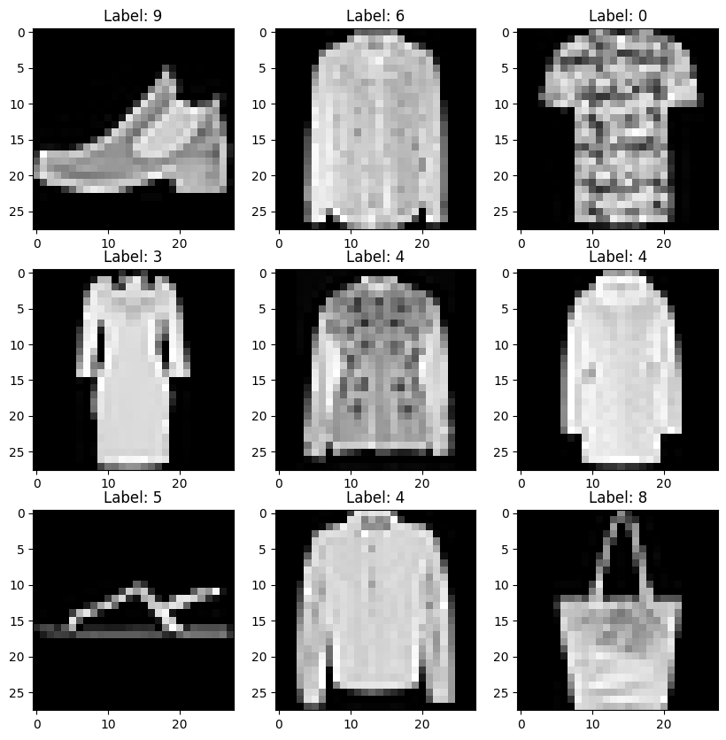

```python
plt.figure(figsize=(10, 10))
for i in range(1, 10):
    plt.subplot(3, 3, i)
    plt.imshow(X[i].reshape(28, 28), cmap='gray')  # Assuming the images are 28x28 pixels
    plt.title(f"Label: {y[i]}")
plt.show()
```

##### `Pixel distribution`

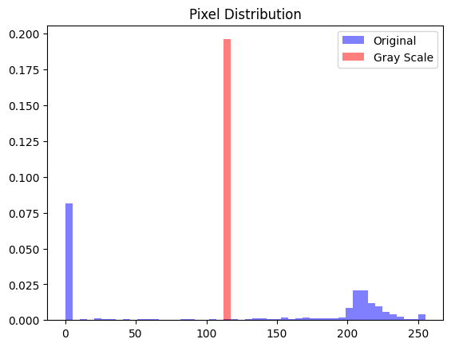

```python
X_train_gray = np.mean(X, axis=1)

def plot_digit(digit_data, shape=(28, 28)):
    plt.imshow(digit_data.reshape(shape), cmap='gray')
    plt.axis('off')

plt.hist(X[0], bins=50, range=(0, 255), density=True, alpha=0.5, color='b', label='Original')
plt.hist(X_train_gray[0], bins=50, range=(0, 255), density=True, alpha=0.5, color='r', label='Gray Scale')
plt.legend()
plt.title('Pixel Distribution')
plt.show()
```

##### `Average image per class`

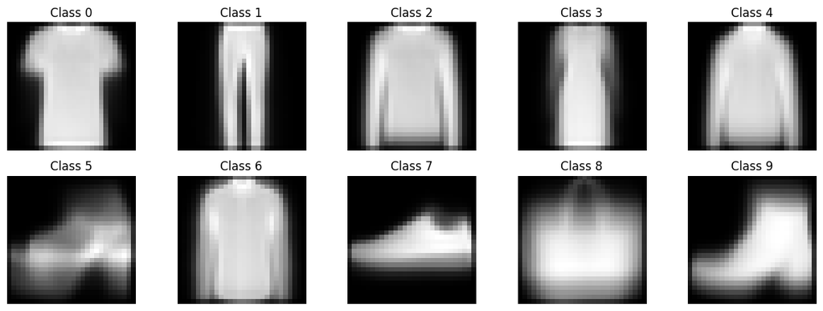

```python
class_labels = np.unique(y_train)
plt.figure(figsize=(15, 8))
for i, label in enumerate(class_labels):
    plt.subplot(3, 5, i + 1)
    class_images = X[y == label]
    average_image = np.mean(class_images, axis=0)
    plot_digit(average_image)
    plt.title(f"Class {label}")
plt.show()
```

##### `Lable distribution`

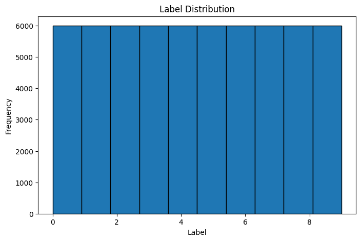

```python
plt.figure(figsize=(8, 5))
plt.hist(y, bins=10, edgecolor='black')
plt.title('Label Distribution')
plt.xlabel('Label')
plt.ylabel('Frequency')
plt.show()
```

##### `Pixel intensity distribution for each class`

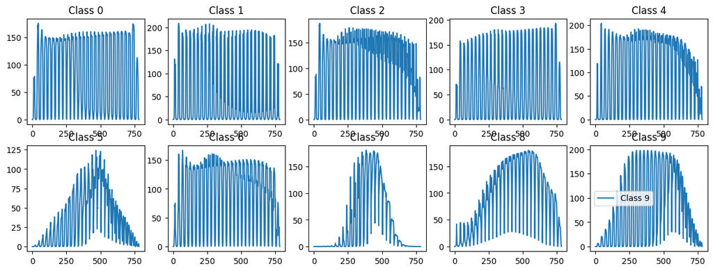

```python
plt.figure(figsize=(15, 8))
for i, label in enumerate(class_labels):
    plt.subplot(3, 5, i + 1)
    class_images = X[y == label]
    pixel_intensity = np.mean(class_images, axis=0)
    plt.plot(pixel_intensity, label=f'Class {label}')
    plt.title(f"Class {label}")
plt.legend()
plt.show()
```

#### **Q3 Define and Train a fully-connected feedforward neural network of your choice using Keras and Tensorflow.**

```python
# Normalize pixel values
X = X.astype('float32') / 255.0

# Split the data into training and temporary sets (80% training, 20% temporary)
X_train, X_temp, y_train, y_temp = train_test_split(X, y, test_size=0.2, random_state=42)
# Split the temporary data into validation and test sets (50% validation, 50% test from the temporary set)
X_val, X_test, y_val, y_test = train_test_split(X_temp, y_temp, test_size=0.5, random_state=42)

# Convert labels to integers
y_train = y_train.astype(int)
y_val = y_val.astype(int)

# Define the model using Sequential API
model = keras.Sequential([
  layers.Flatten(input_shape=(X_train.shape[1],)),  # Flatten input
  layers.Dense(128, activation='relu'),  # First hidden layer with 128 neurons and ReLU activation
  layers.Dense(64, activation='relu'),  # Second hidden layer with 64 neurons and ReLU activation
  layers.Dense(10, activation='softmax')   # Output layer with 10 neurons (fashion categories) and softmax activation
])

# Compile the model, specifying optimizer, loss function, and metrics
model.compile(optimizer='adam',
              loss='sparse_categorical_crossentropy',
              metrics=['accuracy'])
```

#### **Q4 Evaluate the model using the validation dataset. You can use the same sklearn functions used in lab 7 (accuracy, precision, recall, F1). Feel free to expand**

```python
# Predictions on the validation set
y_val_prob = model.predict(X_val)
y_val_pred = y_val_prob.argmax(axis=-1)

# Convert predictions to integers (if needed)
y_val_pred = y_val_pred.astype(int)

# Precision
precision = precision_score(y_val, y_val_pred, average='weighted')

# Recall
recall = recall_score(y_val, y_val_pred, average='weighted')

# F1 score
f1 = f1_score(y_val, y_val_pred, average='weighted')

# Accuracy
accuracy = accuracy_score(y_val, y_val_pred)
print(f'Precision: {precision:.4f}')
print(f'Recall: {recall:.4f}')
print(f'F1 Score: {f1:.4f}')
print(f'Accuracy: {accuracy:.4f}')

# Confusion Matrix
conf_matrix = confusion_matrix(y_val, y_val_pred)
print("\nConfusion Matrix:")
print(conf_matrix)
```

```
188/188 ━━━━━━━━━━━━━━━━━━━━ 1s 2ms/step
Precision: 0.0573
Recall: 0.0985
F1 Score: 0.0404
Accuracy: 0.0985

Confusion Matrix:
[[433   1   0  88   0  99   7   4   1   0]
 [569   0   0  11   2   5   5   0   0   0]
 [362   0   0  34   3 201   5   0   0   0]
 [535   2   0  29   0  60  14   2   2   0]
 [257   0   0  10   3 307   9   0   0   0]
 [251   2   9 143   9 118   2   9  16   5]
 [339   0   0  47   3 227   5   0   0   0]
 [233   0   5 250   2  76  13   2   7   1]
 [272   0   1  50   1 243   0   4   1   0]
 [373   1  11  52   0 139   0   0  18   0]]
```

#### **Q5 Run the model on the test set, and provide clear and relevant conclusions.**

```python
X_test_normalized = X_test.astype('float32') / 255.0

# Evaluate the model on the test set
test_loss, test_accuracy = model.evaluate(X_test_normalized, y_test)

# Print the test loss and accuracy
print(f'Test Loss: {test_loss}')
print(f'Test Accuracy: {test_accuracy}')
```

```
188/188 ━━━━━━━━━━━━━━━━━━━━ 0s 1ms/step - accuracy: 0.0902 - loss: 2.3024
Test Loss: 2.3023881912231445
Test Accuracy: 0.09350000321865082
```

#### `CONCLUSION`

##### The model may be suffering from issues such as overfitting, underfitting, or an insufficiently complex architecture as well as preprocessing or normalization of the data might be impacting on performance.

#### **Q6 What if we wanted to increase the precision for class '5', how can we do that without changing the model or retraining? provide code that exemplifies this.**

```
  1/188 ━━━━━━━━━━━━━━━━━━━━ 5s 30ms/step188/188 ━━━━━━━━━━━━━━━━━━━━ 0s 1ms/step
Precision for class 5 with the new threshold: 0.08294573643410853
New threshold: 0.1
```

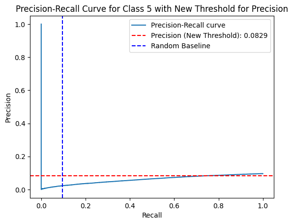

```python
model_predictions = model.predict(X_test)
class_5_probabilities = model_predictions[:, 5]
new_threshold = 0.1
class_5_predicted_labels = (class_5_probabilities >= new_threshold).astype(int)

# Calculating precision for class 5 with the new threshold
precision_class_5_new = precision_score(y_test == 5, class_5_predicted_labels)

print(f'Precision for class 5 with the new threshold: {precision_class_5_new}')
print(f'New threshold: {new_threshold}')

# precision-recall curve with new thhreshold for precision
precision, recall, thresholds = precision_recall_curve(y_test == 5, class_5_probabilities)

plt.plot(recall, precision, label='Precision-Recall curve')
plt.xlabel('Recall')
plt.ylabel('Precision')
plt.title('Precision-Recall Curve for Class 5 with New Threshold for Precision')
plt.axhline(y=precision_class_5_new, color='r', linestyle='--', label=f'Precision (New Threshold): {precision_class_5_new:.4f}')
plt.axvline(x=np.sum(y_test == 5) / len(y_test), color='b', linestyle='--', label='Random Baseline')
plt.legend()
plt.show()
```

#### **Q7 What if we wanted to increase the recall for class '5', how can we do that without changing the model or retraining? provide code that exemplifies this.**

```
Recall for class 5 with the new threshold for recall: 0.7417677642980935
New threshold for recall: 0.1
```

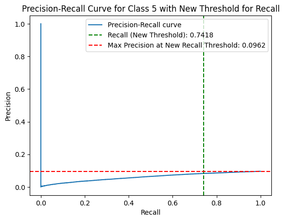

```python
new_recall_threshold = 0.1

class_5_predicted_labels_high_recall = (class_5_probabilities >= new_recall_threshold).astype(int)

# Calculating recall for class 5
recall_class_5_high_recall = recall_score(y_test == 5, class_5_predicted_labels_high_recall)

print(f'Recall for class 5 with the new threshold for recall: {recall_class_5_high_recall}')
print(f'New threshold for recall: {new_recall_threshold}')

# precision-recall curve with the new threshold for recall
precision, recall, thresholds = precision_recall_curve(y_test == 5, class_5_probabilities)

plt.plot(recall, precision, label='Precision-Recall curve')
plt.xlabel('Recall')
plt.ylabel('Precision')
plt.title('Precision-Recall Curve for Class 5 with New Threshold for Recall')
plt.axvline(x=recall_class_5_high_recall, color='g', linestyle='--', label=f'Recall (New Threshold): {recall_class_5_high_recall:.4f}')
plt.axhline(y=precision[recall >= new_recall_threshold].max(), color='r', linestyle='--', label=f'Max Precision at New Recall Threshold: {precision[recall >= new_recall_threshold].max():.4f}')
plt.legend()
plt.show()
```

# `Assignment 9 Avoiding Overfitting by Saving a Model`

##### Step 3: Instead of just one neural network, explore 3 different neural networks (by changing any hyperparameter of your choice) (3 points).

Plot the training and validation loss and accuracy for each one of them. (0.75 points)

For each of the 3 identify the best set of weights based on the graphs or additional considerations where the main purpose is to avoid over-fitting. Use the same reasoning as presented in class (Week 10, Class 2) - which is based on choosing the 'right' epoch. (0.75 points)

As always: summarize your reasoning clearly (table, insights, clear English statements). (1.5 points). clear and good analysis is important. This is evaluate by the depth of you insights, and the clarity of presentation.

```python
# Define and train the first neural network
model_1 = keras.Sequential([
    layers.Dense(128, activation='relu', input_shape=(X_train.shape[1],)),
    layers.Dense(64, activation='relu'),
    layers.Dense(10, activation='softmax')
])
model_1.compile(optimizer='adam', loss='sparse_categorical_crossentropy', metrics=['accuracy'])
history_1 = model_1.fit(X_train, y_train, epochs=10, validation_data=(X_val, y_val))

# Define and train the second neural network with different hyperparameters
model_2 = keras.Sequential([
    layers.Dense(256, activation='relu', input_shape=(X_train.shape[1],)),
    layers.Dense(128, activation='relu'),
    layers.Dense(64, activation='relu'),
    layers.Dense(10, activation='softmax')
])
model_2.compile(optimizer='adam', loss='sparse_categorical_crossentropy', metrics=['accuracy'])
history_2 = model_2.fit(X_train, y_train, epochs=10, validation_data=(X_val, y_val))

# Define and train the third neural network with different hyperparameters
model_3 = keras.Sequential([
    layers.Dense(64, activation='relu', input_shape=(X_train.shape[1],)),
    layers.Dense(32, activation='relu'),
    layers.Dense(10, activation='softmax')
])
model_3.compile(optimizer='adam', loss='sparse_categorical_crossentropy', metrics=['accuracy'])
history_3 = model_3.fit(X_train, y_train, epochs=10, validation_data=(X_val, y_val))
```

```
1500/1500 ━━━━━━━━━━━━━━━━━━━━ 4s 2ms/step - accuracy: 0.7571 - loss: 0.7037 - val_accuracy: 0.8450 - val_loss: 0.4187
1500/1500 ━━━━━━━━━━━━━━━━━━━━ 3s 2ms/step - accuracy: 0.8545 - loss: 0.4031 - val_accuracy: 0.8663 - val_loss: 0.3823
1500/1500 ━━━━━━━━━━━━━━━━━━━━ 3s 2ms/step - accuracy: 0.8737 - loss: 0.3482 - val_accuracy: 0.8687 - val_loss: 0.3540
1500/1500 ━━━━━━━━━━━━━━━━━━━━ 3s 2ms/step - accuracy: 0.8809 - loss: 0.3254 - val_accuracy: 0.8737 - val_loss: 0.3326
1500/1500 ━━━━━━━━━━━━━━━━━━━━ 3s 2ms/step - accuracy: 0.8873 - loss: 0.3040 - val_accuracy: 0.8765 - val_loss: 0.3269
1500/1500 ━━━━━━━━━━━━━━━━━━━━ 3s 2ms/step - accuracy: 0.8940 - loss: 0.2839 - val_accuracy: 0.8845 - val_loss: 0.3177
1500/1500 ━━━━━━━━━━━━━━━━━━━━ 3s 2ms/step - accuracy: 0.8994 - loss: 0.2753 - val_accuracy: 0.8663 - val_loss: 0.3570
1500/1500 ━━━━━━━━━━━━━━━━━━━━ 3s 2ms/step - accuracy: 0.9019 - loss: 0.2662 - val_accuracy: 0.8805 - val_loss: 0.3328
1500/1500 ━━━━━━━━━━━━━━━━━━━━ 3s 2ms/step - accuracy: 0.9027 - loss: 0.2573 - val_accuracy: 0.8880 - val_loss: 0.3149
1500/1500 ━━━━━━━━━━━━━━━━━━━━ 3s 2ms/step - accuracy: 0.9055 - loss: 0.2478 - val_accuracy: 0.8852 - val_loss: 0.3266
1500/1500 ━━━━━━━━━━━━━━━━━━━━ 6s 3ms/step - accuracy: 0.7581 - loss: 0.6672 - val_accuracy: 0.8458 - val_loss: 0.4267
1500/1500 ━━━━━━━━━━━━━━━━━━━━ 5s 3ms/step - accuracy: 0.8602 - loss: 0.3882 - val_accuracy: 0.8687 - val_loss: 0.3714
1500/1500 ━━━━━━━━━━━━━━━━━━━━ 5s 3ms/step - accuracy: 0.8743 - loss: 0.3474 - val_accuracy: 0.8605 - val_loss: 0.3812
1500/1500 ━━━━━━━━━━━━━━━━━━━━ 5s 3ms/step - accuracy: 0.8815 - loss: 0.3184 - val_accuracy: 0.8792 - val_loss: 0.3255
1500/1500 ━━━━━━━━━━━━━━━━━━━━ 4s 3ms/step - accuracy: 0.8869 - loss: 0.3020 - val_accuracy: 0.8800 - val_loss: 0.3317
1500/1500 ━━━━━━━━━━━━━━━━━━━━ 5s 3ms/step - accuracy: 0.8977 - loss: 0.2802 - val_accuracy: 0.8870 - val_loss: 0.3074
1500/1500 ━━━━━━━━━━━━━━━━━━━━ 4s 3ms/step - accuracy: 0.9016 - loss: 0.2638 - val_accuracy: 0.8772 - val_loss: 0.3343
1500/1500 ━━━━━━━━━━━━━━━━━━━━ 5s 3ms/step - accuracy: 0.9042 - loss: 0.2557 - val_accuracy: 0.8822 - val_loss: 0.3220
1500/1500 ━━━━━━━━━━━━━━━━━━━━ 5s 3ms/step - accuracy: 0.9075 - loss: 0.2472 - val_accuracy: 0.8932 - val_loss: 0.2892
1500/1500 ━━━━━━━━━━━━━━━━━━━━ 5s 3ms/step - accuracy: 0.9131 - loss: 0.2320 - val_accuracy: 0.8860 - val_loss: 0.3232
1500/1500 ━━━━━━━━━━━━━━━━━━━━ 3s 2ms/step - accuracy: 0.7407 - loss: 0.7401 - val_accuracy: 0.8497 - val_loss: 0.4178
1500/1500 ━━━━━━━━━━━━━━━━━━━━ 2s 1ms/step - accuracy: 0.8497 - loss: 0.4175 - val_accuracy: 0.8608 - val_loss: 0.3816
1500/1500 ━━━━━━━━━━━━━━━━━━━━ 2s 2ms/step - accuracy: 0.8689 - loss: 0.3655 - val_accuracy: 0.8712 - val_loss: 0.3572
1500/1500 ━━━━━━━━━━━━━━━━━━━━ 2s 1ms/step - accuracy: 0.8758 - loss: 0.3418 - val_accuracy: 0.8603 - val_loss: 0.3902
1500/1500 ━━━━━━━━━━━━━━━━━━━━ 2s 1ms/step - accuracy: 0.8786 - loss: 0.3283 - val_accuracy: 0.8758 - val_loss: 0.3426
1500/1500 ━━━━━━━━━━━━━━━━━━━━ 2s 1ms/step - accuracy: 0.8883 - loss: 0.3036 - val_accuracy: 0.8765 - val_loss: 0.3482
1500/1500 ━━━━━━━━━━━━━━━━━━━━ 2s 1ms/step - accuracy: 0.8908 - loss: 0.2944 - val_accuracy: 0.8865 - val_loss: 0.3217
1500/1500 ━━━━━━━━━━━━━━━━━━━━ 2s 1ms/step - accuracy: 0.8940 - loss: 0.2903 - val_accuracy: 0.8815 - val_loss: 0.3281
1500/1500 ━━━━━━━━━━━━━━━━━━━━ 2s 1ms/step - accuracy: 0.8968 - loss: 0.2715 - val_accuracy: 0.8867 - val_loss: 0.3358
1500/1500 ━━━━━━━━━━━━━━━━━━━━ 2s 1ms/step - accuracy: 0.9013 - loss: 0.2691 - val_accuracy: 0.8820 - val_loss: 0.3289
```

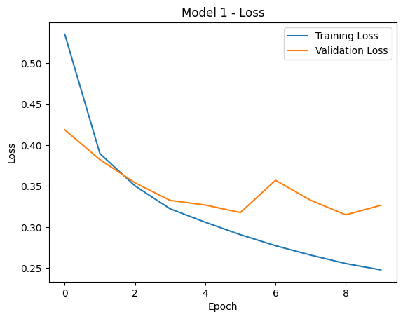

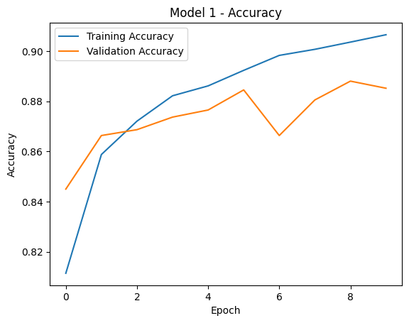

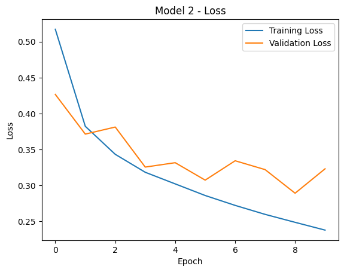

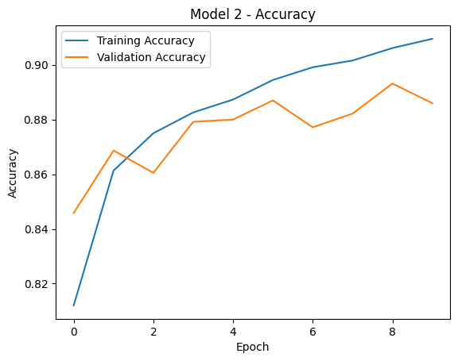

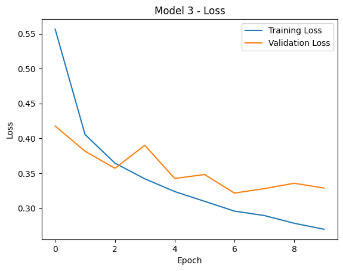

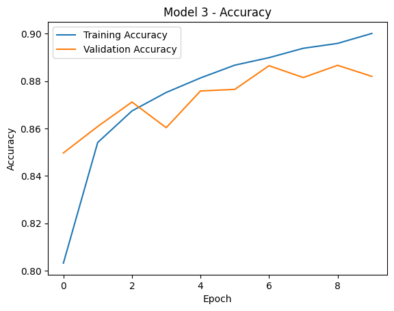

```python
def plot_metrics(history, model_name):
    plt.plot(history.history['loss'], label='Training Loss')
    plt.plot(history.history['val_loss'], label='Validation Loss')
    plt.title(f'{model_name} - Loss')
    plt.xlabel('Epoch')
    plt.ylabel('Loss')
    plt.legend()
    plt.show()

    plt.plot(history.history['accuracy'], label='Training Accuracy')
    plt.plot(history.history['val_accuracy'], label='Validation Accuracy')
    plt.title(f'{model_name} - Accuracy')
    plt.xlabel('Epoch')
    plt.ylabel('Accuracy')
    plt.legend()
    plt.show()

plot_metrics(history_1, 'Model 1')
plot_metrics(history_2, 'Model 2')
plot_metrics(history_3, 'Model 3')
```

```python
# Define the models
models = [model_1, model_2, model_3]

# Print summary for each model
for i, model in enumerate(models, 1):
    print(f"Model {i}:"," Summary")
    model.summary()
    print("\n")
```

```
Model 1:  Summary
```

```
Model: "sequential_5"
```

```
┏━━━━━━━━━━━━━━━━━━━━━━━━━━━━━━━━━┳━━━━━━━━━━━━━━━━━━━━━━━━┳━━━━━━━━━━━━━━━┓
┃ Layer (type)                    ┃ Output Shape           ┃       Param # ┃
┡━━━━━━━━━━━━━━━━━━━━━━━━━━━━━━━━━╇━━━━━━━━━━━━━━━━━━━━━━━━╇━━━━━━━━━━━━━━━┩
│ dense_16 (Dense)                │ (None, 128)            │       100,480 │
├─────────────────────────────────┼────────────────────────┼───────────────┤
│ dense_17 (Dense)                │ (None, 64)             │         8,256 │
├─────────────────────────────────┼────────────────────────┼───────────────┤
│ dense_18 (Dense)                │ (None, 10)             │           650 │
└─────────────────────────────────┴────────────────────────┴───────────────┘
```

```
 Total params: 328,160 (1.25 MB)
```

```
 Trainable params: 109,386 (427.29 KB)
```

```
 Non-trainable params: 0 (0.00 B)
```

```
 Optimizer params: 218,774 (854.59 KB)
```

```
Model 2:  Summary
```

```
Model: "sequential_6"
```

```
┏━━━━━━━━━━━━━━━━━━━━━━━━━━━━━━━━━┳━━━━━━━━━━━━━━━━━━━━━━━━┳━━━━━━━━━━━━━━━┓
┃ Layer (type)                    ┃ Output Shape           ┃       Param # ┃
┡━━━━━━━━━━━━━━━━━━━━━━━━━━━━━━━━━╇━━━━━━━━━━━━━━━━━━━━━━━━╇━━━━━━━━━━━━━━━┩
│ dense_19 (Dense)                │ (None, 256)            │       200,960 │
├─────────────────────────────────┼────────────────────────┼───────────────┤
│ dense_20 (Dense)                │ (None, 128)            │        32,896 │
├─────────────────────────────────┼────────────────────────┼───────────────┤
│ dense_21 (Dense)                │ (None, 64)             │         8,256 │
├─────────────────────────────────┼────────────────────────┼───────────────┤
│ dense_22 (Dense)                │ (None, 10)             │           650 │
└─────────────────────────────────┴────────────────────────┴───────────────┘
```

```
 Total params: 728,288 (2.78 MB)
```

```
 Trainable params: 242,762 (948.29 KB)
```

```
 Non-trainable params: 0 (0.00 B)
```

```
 Optimizer params: 485,526 (1.85 MB)
```

```
Model 3:  Summary
```

```
Model: "sequential_7"
```

```
┏━━━━━━━━━━━━━━━━━━━━━━━━━━━━━━━━━┳━━━━━━━━━━━━━━━━━━━━━━━━┳━━━━━━━━━━━━━━━┓
┃ Layer (type)                    ┃ Output Shape           ┃       Param # ┃
┡━━━━━━━━━━━━━━━━━━━━━━━━━━━━━━━━━╇━━━━━━━━━━━━━━━━━━━━━━━━╇━━━━━━━━━━━━━━━┩
│ dense_23 (Dense)                │ (None, 64)             │        50,240 │
├─────────────────────────────────┼────────────────────────┼───────────────┤
│ dense_24 (Dense)                │ (None, 32)             │         2,080 │
├─────────────────────────────────┼────────────────────────┼───────────────┤
│ dense_25 (Dense)                │ (None, 10)             │           330 │
└─────────────────────────────────┴────────────────────────┴───────────────┘
```

```
 Total params: 157,952 (617.00 KB)
```

```
 Trainable params: 52,650 (205.66 KB)
```

```
 Non-trainable params: 0 (0.00 B)
```

```
 Optimizer params: 105,302 (411.34 KB)
```

### Model 1:

- **Architecture:** This model has 3 layers.
- **Size:** It has a moderate size, with around 328,160 parameters.
- **Trainable Parameters:** About 109,386 parameters can be adjusted during training.
- **Memory Usage:** The model occupies approximately 1.25 MB of memory.
- **Complexity:** It's moderately complex.

### Model 2:

- **Architecture:** This model has 4 layers.
- **Size:** It's larger compared to Model 1, with around 728,288 parameters.
- **Trainable Parameters:** Approximately 242,762 parameters can be adjusted during training.
- **Memory Usage:** The model occupies approximately 2.78 MB of memory.
- **Complexity:** It's more complex than Model 1.

### Model 3:

- **Architecture:** This model has 3 layers.
- **Size:** It's the smallest among the three models, with around 157,952 parameters.
- **Trainable Parameters:** Only about 52,650 parameters can be adjusted during training.
- **Memory Usage:** The model occupies approximately 617.00 KB of memory.
- **Complexity:** It's the simplest and least complex of the three models.

```python
# Save the best model during training
checkpoint_filepath = 'C:/Foundations_of_Machine_Learning_Frameworks_lab/Labs/lab1/CSCN8010-labs-simardeep-singh/best_model.keras'
model_checkpoint_callback = keras.callbacks.ModelCheckpoint(
    filepath=checkpoint_filepath,
    save_weights_only=False,
    monitor='val_loss',
    mode='min',
    save_best_only=True
)

# Train the model with the callback to save the best model
history = model.fit(X_train, y_train, epochs=10, validation_data=(X_val, y_val), callbacks=[model_checkpoint_callback])

# Load the saved best model
best_model = keras.models.load_model(checkpoint_filepath)

# Evaluate the best model on the test set
test_loss, test_accuracy = best_model.evaluate(X_test, y_test)
print(f"Test Loss: {test_loss}")
print(f"Test Accuracy: {test_accuracy}")
```

```
1500/1500 ━━━━━━━━━━━━━━━━━━━━ 2s 1ms/step - accuracy: 0.9050 - loss: 0.2597 - val_accuracy: 0.8858 - val_loss: 0.3278
1500/1500 ━━━━━━━━━━━━━━━━━━━━ 2s 1ms/step - accuracy: 0.9057 - loss: 0.2540 - val_accuracy: 0.8878 - val_loss: 0.3124
1500/1500 ━━━━━━━━━━━━━━━━━━━━ 2s 1ms/step - accuracy: 0.9077 - loss: 0.2416 - val_accuracy: 0.8867 - val_loss: 0.3195
1500/1500 ━━━━━━━━━━━━━━━━━━━━ 2s 1ms/step - accuracy: 0.9106 - loss: 0.2390 - val_accuracy: 0.8872 - val_loss: 0.3152
1500/1500 ━━━━━━━━━━━━━━━━━━━━ 2s 1ms/step - accuracy: 0.9145 - loss: 0.2360 - val_accuracy: 0.8905 - val_loss: 0.3251
1500/1500 ━━━━━━━━━━━━━━━━━━━━ 2s 1ms/step - accuracy: 0.9139 - loss: 0.2311 - val_accuracy: 0.8803 - val_loss: 0.3471
1500/1500 ━━━━━━━━━━━━━━━━━━━━ 2s 1ms/step - accuracy: 0.9174 - loss: 0.2243 - val_accuracy: 0.8903 - val_loss: 0.3087
1500/1500 ━━━━━━━━━━━━━━━━━━━━ 2s 1ms/step - accuracy: 0.9210 - loss: 0.2132 - val_accuracy: 0.8965 - val_loss: 0.3082
1500/1500 ━━━━━━━━━━━━━━━━━━━━ 2s 1ms/step - accuracy: 0.9202 - loss: 0.2114 - val_accuracy: 0.8850 - val_loss: 0.3400
1500/1500 ━━━━━━━━━━━━━━━━━━━━ 2s 1ms/step - accuracy: 0.9209 - loss: 0.2096 - val_accuracy: 0.8973 - val_loss: 0.3191
188/188 ━━━━━━━━━━━━━━━━━━━━ 0s 1ms/step - accuracy: 0.8869 - loss: 0.3201
Test Loss: 0.33859655261039734
Test Accuracy: 0.8863333463668823
```

### Analysis

The model did quite well during training, and it performed similarly on new data (validation set) too. However, when I tested it on test set, its performance dropped a bit, which is expected. This means the model may need some improvements to perform better on new, unseen data.